# projectReport.Rmd

DS 202 Group 9

5/1/2021

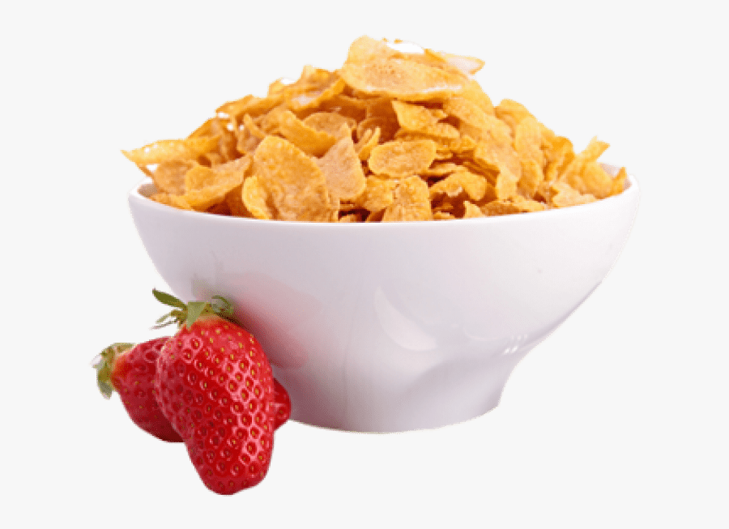

A bowl of cereal

## Questions Raised

Our group came up with the following questions that may impact the choice that an everyday consumer might make when purchasing cereal.

These questions include:

1. What is the correlation between nutritional values and rating?
2. What manufacturers have the most top shelf and bottom shelf cereals?
3. What are the healthiest and least healthiest cold cereals?
4. Do people prefer hot or cold cereal based off of the rating?
5. Which manufacturers have the highest average rating?
6. Who are the “healthiest” and “least healthiest” manufacturers?
7. What is a healthy cereal for kids based off of nutritional facts?
8. What is a healthy cereal for adults/elders based off of nutritional facts?
9. How much of the best/worst cereals can one have before exceeding recommended levels?
10. Which shelf has the higher average rating?

## Obtaining and Cleaning the Dataset

The cereal information that we are using is from a website called Kaggle. The link to download the .csv file can be found [here](https://www.kaggle.com/crawford/80-cereals). A limiting constraint that this data set possesses is that we do not have any null values. Instead of null values, we have -1s in their place. To work around this, we decided to alter the columns that were needed to answer our questions by only keeping values that were 0 or above. This allowed us to remove the null values without methods such as na.omit() in dplyr functions. Other than that, the data set was clean for the most part.

## Answers to the quesitons raised

After coming up with our questions, we decided to explore the data to try and find conclusions to the questions that were raised above. This section will show our thought process for answering each question, as well as the code that helped us come to our conclusions. Here are our results:

**1) What is the correlation between nutritional values and rating? (Answered by Nathan Marquardt)**

For this question, I first needed to take away any null values (in the form of -1). To do this, I created a data frame for each category that for each category only had values that were 0 and above. After this, I created a correlation result using cor() to find the correlation value between each category compared to the rating value. After all the correlations were calculated, I then created a new dataframe with each category name as a column and their values as a column. Here is my code below.

```
##   category       value
## 1    Fiber  0.58416042
## 2  Protein  0.47061846
## 3   Potass  0.41600873
## 4    Carbo  0.08871244
## 5   Sodium -0.40129520
## 6      Fat -0.40928366
## 7 Calories -0.68937603
## 8   Sugars -0.76390195
```

**2) What manufacturers have the most top shelf and bottom shelf cereals? (Answered by Alex Son)**

I had pulled out the “mfr” and “shelf” to make it easier to see for this question. Then I had filtered out the rows at shelf 3 for the top shelf and counted the numbers down for the manufacturers.

```
## # A tibble: 6 x 2
##   mfr       n
## * <chr> <int>
## 1 G         9
## 2 K        12
## 3 N         1
## 4 P         6
## 5 Q         4
## 6 R         4
```

On the other hand, I had done the same process for the shelf ==“1,” which is the bottom shelf cereals.

```
## # A tibble: 6 x 2
##   mfr       n
## * <chr> <int>
## 1 G         6
## 2 K         4
## 3 N         3
## 4 P         2
## 5 Q         1
## 6 R         4
```

**3) What are the healthiest and least healthiest cold cereals? (Answered by Vismay Gehlot)**

To find this, I used the cold cereal filtered data set that Madalyn created and worked off that. We had established that the two factors in determining a healthy or unhealthy cereal depended on the amount of fiber and sugars in each cereal, so I decided to make an ordered list of the data set sorting by fiber in descending and sugar in ascending. This ordered the data set into a list that had the highest fiber with the lowest sugr and went down. From this list, I learned that All-Bran with Extra Fiber is the healthiest cold cereal as it contains 14 grams of fiber with no sugar per serving.

```
## # A tibble: 6 x 16
##   name  mfr   type  calories protein   fat sodium fiber carbo sugars potass
##   <chr> <chr> <chr>    <dbl>   <dbl> <dbl>  <dbl> <dbl> <dbl>  <dbl>  <dbl>
## 1 All-~ K     C           50       4     0    140    14     8      0    330
## 2 100%~ N     C           70       4     1    130    10     5      6    280
## 3 All-~ K     C           70       4     1    260     9     7      5    320
## 4 Post~ P     C          120       3     1    200     6    11     14    260
## 5 Bran~ P     C           90       3     0    210     5    13      5    190
## 6 Frui~ P     C          120       3     2    160     5    12     10    200
## # ... with 5 more variables: vitamins <dbl>, shelf <dbl>, weight <dbl>,
## #   cups <dbl>, rating <dbl>
```

To figure out the least healthiest cereal, I did the opposite of wht I stated above, making a list of cereals with fiber in ascending order and sugar in descending. This allowed me to see that Golden Crisp is the unhealthiest cereal, as it has no fiber and 15 grams of sugar per serving.

```
## # A tibble: 6 x 16
##   name  mfr   type  calories protein   fat sodium fiber carbo sugars potass
##   <chr> <chr> <chr>    <dbl>   <dbl> <dbl>  <dbl> <dbl> <dbl>  <dbl>  <dbl>
## 1 Gold~ P     C          100       2     0     45     0    11     15     40
## 2 Coco~ G     C          110       1     1    180     0    12     13     55
## 3 Coun~ G     C          110       1     1    180     0    12     13     65
## 4 Cap'~ Q     C          120       1     2    220     0    12     12     35
## 5 Frui~ P     C          110       1     1    135     0    13     12     25
## 6 Luck~ G     C          110       2     1    180     0    12     12     55
## # ... with 5 more variables: vitamins <dbl>, shelf <dbl>, weight <dbl>,
## #   cups <dbl>, rating <dbl>
```

**4) Do people prefer hot or cold cereal based off of the rating? (Answered by Madalyn Mueller)**

```
## [1] 42.09522
```

```
## [1] 56.73771
```

```
## # A tibble: 74 x 16
##    name  mfr   type  calories protein   fat sodium fiber carbo sugars potass
##    <chr> <chr> <chr>    <dbl>   <dbl> <dbl>  <dbl> <dbl> <dbl>  <dbl>  <dbl>
##  1 Cap'~ Q     C          120       1     2    220     0    12     12     35
##  2 Cinn~ G     C          120       1     3    210     0    13      9     45
##  3 Hone~ Q     C          120       1     2    220     1    12     11     45
##  4 Coun~ G     C          110       1     1    180     0    12     13     65
##  5 Coco~ G     C          110       1     1    180     0    12     13     55
##  6 Gold~ G     C          110       1     1    280     0    15      9     45
##  7 Luck~ G     C          110       2     1    180     0    12     12     55
##  8 Trix  G     C          110       1     1    140     0    13     12     25
##  9 Frui~ P     C          110       1     1    135     0    13     12     25
## 10 Tota~ G     C          140       3     1    190     4    15     14    230
## # ... with 64 more rows, and 5 more variables: vitamins <dbl>, shelf <dbl>,
## #   weight <dbl>, cups <dbl>, rating <dbl>
```

```
## # A tibble: 3 x 16
##   name  mfr   type  calories protein   fat sodium fiber carbo sugars potass
##   <chr> <chr> <chr>    <dbl>   <dbl> <dbl>  <dbl> <dbl> <dbl>  <dbl>  <dbl>
## 1 Quak~ Q     H          100       5     2      0   2.7    -1     -1    110
## 2 Maypo A     H          100       4     1      0   0      16      3     95
## 3 Crea~ N     H          100       3     0     80   1      21      0     -1
## # ... with 5 more variables: vitamins <dbl>, shelf <dbl>, weight <dbl>,
## #   cups <dbl>, rating <dbl>
```

```
## # A tibble: 77 x 16
##    name  mfr   type  calories protein   fat sodium fiber carbo sugars potass
##    <chr> <chr> <chr>    <dbl>   <dbl> <dbl>  <dbl> <dbl> <dbl>  <dbl>  <dbl>
##  1 Cap'~ Q     C          120       1     2    220     0    12     12     35
##  2 Cinn~ G     C          120       1     3    210     0    13      9     45
##  3 Hone~ Q     C          120       1     2    220     1    12     11     45
##  4 Coun~ G     C          110       1     1    180     0    12     13     65
##  5 Coco~ G     C          110       1     1    180     0    12     13     55
##  6 Gold~ G     C          110       1     1    280     0    15      9     45
##  7 Luck~ G     C          110       2     1    180     0    12     12     55
##  8 Trix  G     C          110       1     1    140     0    13     12     25
##  9 Frui~ P     C          110       1     1    135     0    13     12     25
## 10 Tota~ G     C          140       3     1    190     4    15     14    230
## # ... with 67 more rows, and 5 more variables: vitamins <dbl>, shelf <dbl>,
## #   weight <dbl>, cups <dbl>, rating <dbl>
```

To find this, I first made two filtered data sets of cold and hot cereals, and then printed the mean rating for both of these data sets. I realized this was not the best way to compare the ratings, so I decided to do a different approach.

**5) Which manufacturer has the highest average rating?(by Madalyn Mueller)**

To find this, I made filtered data sets of all 7 of the manufacturers (American Home Food Products, General Mills, Kelloggs, Nabisco, Post, Quaker Oats, Ralston Purina). Then I printed the average/mean ratings for each filtered data set.

Nabisco is the manufacturer with the highest average rating. This makes sense, because five out of the 10 highest rated cereals are produced by Nabisco. Their cereals include 100% Bran, Cream of Wheat, Shredded Wheat, and Strawberry Fruit Wheats.

```
## [1] 67.96857
```

```
## [1] 42.91599
```

```
## [1] 44.03846
```

```
## [1] 41.543
```

```
## [1] 34.48585
```

```
## [1] 41.70574
```

```
## [1] 54.85092
```

**6) Who are the “healthiest” and “least healthiest” manufacturers? (Answered by Mike Brown)**

Which is the healthiest manufacturer?

Answering this question required me to summarize the mean sugar and fiber content for each manufacturer. I then filtered the results to show the manufacturers that met the guidelines for a healthy cereal as defined by our source from the Cleveland Clinic (sugar < 6g/serving, fiber > 2.5g/serving). The only manufacturer to meet this criteria was Nabisco, but to better visualize how the other manufacturers placed, I made two graphs displaying the distribution of sugar and fiber content between the various manufacturers.

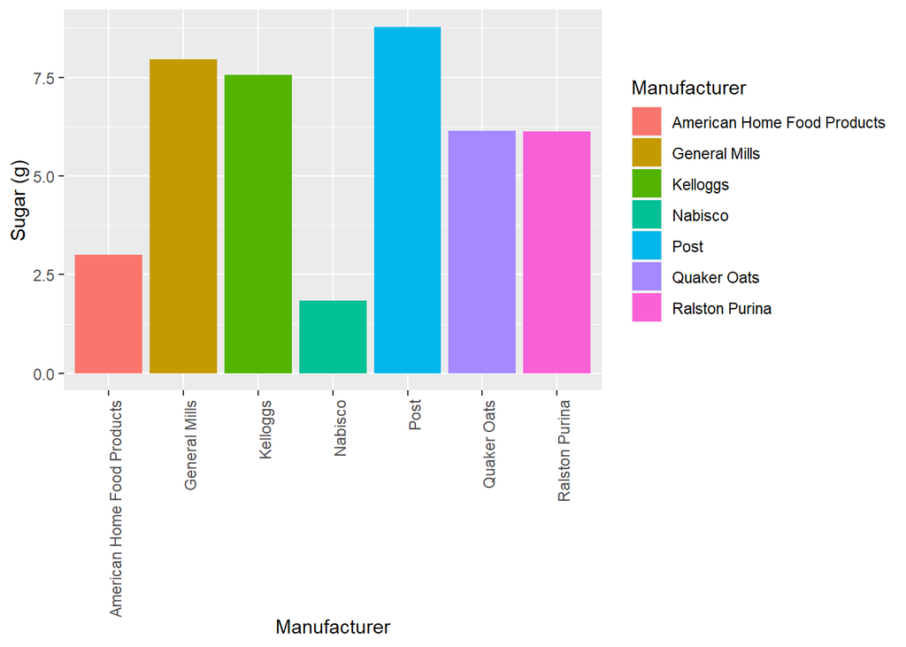

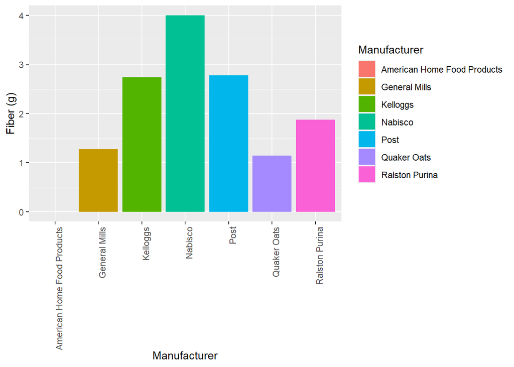

Which is the least healthy manufacturer?

This question is just the opposite of my first one. I used the same dataset of summarized sugar and fiber content but instead selected the manufacturers that were opposite to the recommendations from Cleveland Clinic. This yielded 3 results that weren’t overwhelmingly obvious which is the worst. Ralston Purina is not that far from being considered healthy and Quaker Oats wasn’t far from meeting the sugar requirement. General Mills had much more sugar than the rest and not much different fiber content, so I decided that General Mills was the least healthy of all.

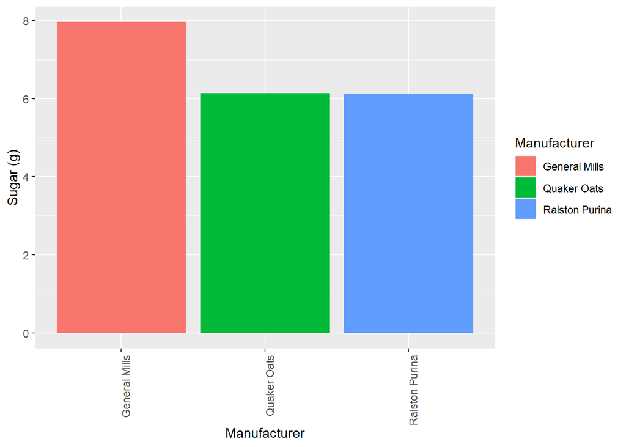

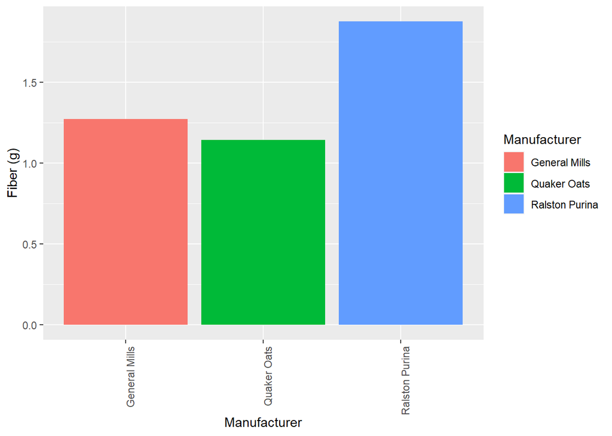

**7) What is a healthy cereal for kids based off of nutritional facts? (Answered by Sydney Thompson)**

All values of fiber and sodium for all ages were calculated with the use of nutritional data from the USDA daily intake summary table. Using the values for fiber and sodium, depending on the age range from the table, I made a ratio of the daily values and average cups per serving of cereal to compute the fiber and sodium values for breakfast intake only. These values are shown below within each age range of code:

Kids 4-8 years of age:

```
## # A tibble: 2 x 16
##   name  mfr   type  calories protein   fat sodium fiber carbo sugars potass
##   <chr> <chr> <chr>    <dbl>   <dbl> <dbl>  <dbl> <dbl> <dbl>  <dbl>  <dbl>
## 1 100%~ N     C           70       4     1    130    10     5      6    280
## 2 All-~ K     C           50       4     0    140    14     8      0    330
## # ... with 5 more variables: vitamins <dbl>, shelf <dbl>, weight <dbl>,
## #   cups <dbl>, rating <dbl>
```

Kids 9-13 years of age:

```
## # A tibble: 2 x 16
##   name  mfr   type  calories protein   fat sodium fiber carbo sugars potass
##   <chr> <chr> <chr>    <dbl>   <dbl> <dbl>  <dbl> <dbl> <dbl>  <dbl>  <dbl>
## 1 100%~ N     C           70       4     1    130    10     5      6    280
## 2 All-~ K     C           50       4     0    140    14     8      0    330
## # ... with 5 more variables: vitamins <dbl>, shelf <dbl>, weight <dbl>,
## #   cups <dbl>, rating <dbl>
```

As a result, all age ranges shown above should purchase 100% Bran and/or All-Bran with Extra Fiber cereals when looking for a healthy cereal to consume based on fiber and sodium intake values.

**8) What is a healthy cereal for adults/elders based off of nutritional facts? (Answered by Sydney Thompson)**

All values of fiber and sodium for all ages were calculated with the use of nutritional data from the USDA daily intake summary table. Using the values for fiber and sodium, depending on the age range from the table, I made a ratio of the daily values and average cups per serving of cereal to compute the fiber and sodium values for breakfast intake only. These values are shown below within each age range of code:

Males 19-50 years of age:

```
## # A tibble: 2 x 16
##   name  mfr   type  calories protein   fat sodium fiber carbo sugars potass
##   <chr> <chr> <chr>    <dbl>   <dbl> <dbl>  <dbl> <dbl> <dbl>  <dbl>  <dbl>
## 1 100%~ N     C           70       4     1    130    10     5      6    280
## 2 All-~ K     C           50       4     0    140    14     8      0    330
## # ... with 5 more variables: vitamins <dbl>, shelf <dbl>, weight <dbl>,
## #   cups <dbl>, rating <dbl>
```

Females 19-50 years of age:

```
## # A tibble: 3 x 16
##   name  mfr   type  calories protein   fat sodium fiber carbo sugars potass
##   <chr> <chr> <chr>    <dbl>   <dbl> <dbl>  <dbl> <dbl> <dbl>  <dbl>  <dbl>
## 1 100%~ N     C           70       4     1    130    10     5      6    280
## 2 All-~ K     C           50       4     0    140    14     8      0    330
## 3 Post~ P     C          120       3     1    200     6    11     14    260
## # ... with 5 more variables: vitamins <dbl>, shelf <dbl>, weight <dbl>,
## #   cups <dbl>, rating <dbl>
```

Males 70+ years of age:

```
## # A tibble: 2 x 16
##   name  mfr   type  calories protein   fat sodium fiber carbo sugars potass
##   <chr> <chr> <chr>    <dbl>   <dbl> <dbl>  <dbl> <dbl> <dbl>  <dbl>  <dbl>
## 1 100%~ N     C           70       4     1    130    10     5      6    280
## 2 All-~ K     C           50       4     0    140    14     8      0    330
## # ... with 5 more variables: vitamins <dbl>, shelf <dbl>, weight <dbl>,
## #   cups <dbl>, rating <dbl>
```

Females 70+ years of age:

```
## # A tibble: 2 x 16
##   name  mfr   type  calories protein   fat sodium fiber carbo sugars potass
##   <chr> <chr> <chr>    <dbl>   <dbl> <dbl>  <dbl> <dbl> <dbl>  <dbl>  <dbl>
## 1 100%~ N     C           70       4     1    130    10     5      6    280
## 2 All-~ K     C           50       4     0    140    14     8      0    330
## # ... with 5 more variables: vitamins <dbl>, shelf <dbl>, weight <dbl>,
## #   cups <dbl>, rating <dbl>
```

As a result, all age ranges shown above should purchase 100% Bran and/or All-Bran with Extra Fiber cereals when looking for a healthy cereal to consume based on fiber and sodium intake values.

**9) How much of the best/worst cereals can one have before exceeding recommended levels? (Answered by Sydney Thompson)**

Using the same USDA daily intake summary table, I made a ratio of daily calories to meals per day to compute the amount of calories a male and female should consume approximately for breakfast and I concluded that men should have roughly 600 calories and females should have 500. After calculating the two I found the calories per serving in cups for the healthiest cereal, All-Bran with Extra Fiber, and the least healthiest cereal, Gold Crisp, stated earlier by Vismay. With those values I created a simple equation of dividing the male and female calorie intake by the amount of calories per serving and then multiplied that value by the amount of cereal in cups.

```
## [1] 6
```

```
## [1] 5.28
```

```
## [1] 5
```

```
## [1] 4.4
```

I found that men can have roughly 6 cups of the healthiest cereal and about 5.28 cups of the least healthiest cereal and for women 5 cups of the healthiest and 4.4 cups of the least healthiest. That being said, it is reasonable for men to be able to consume more than women as they are usually greater in weight than women thus needing to eat more food to keep their body full.

**10) Which shelf has the higher average rating? (Answered by Nathan Marquardt)**

## Contributions

### Alex Son

1. The questions I had were “What manufacturers have the most top shelf and bottom shelf cereals?” The brand “Kellogg” had the most top-shelf cereals, and the brand “General Mills” had the most bottom shelf cereals.

The questions I’d got for this project were more manageable than the questions that other guys had, so I tried to cooperate and be in the meetings as much as possible. Also, I am in charge of going through the last part of our presentation, for summing up and telling the challenges we had during our project.

### Madalyn Mueller

1. Do people prefer hot or cold cereal based off of the rating?

To find this, I first made two filtered data sets of cold and hot cereals, and then printed the mean rating for both of these data sets. I realized this was not the best way to compare the ratings, so I decided to do a different approach.

2. Which manufacturer has the highest average rating?

To find this, I made filtered data sets of all 7 of the manufacturers (American Home Food Products, General Mills, Kelloggs, Nabisco, Post, Quaker Oats, Ralston Purina). Then I printed the average/mean ratings for each filtered data set.

Nabisco is the manufacturer with the highest average rating. This makes sense, because five out of the 10 highest rated cereals are produced by Nabisco. Their cereals include 100% Bran, Cream of Wheat, Shredded Wheat, and Strawberry Fruit Wheats.

### Mike Brown

I assisted the group with building the presentation and writing the project report. Apart from this I had two questions to answer which are which is the healthiest manufacturer and which is the least healthy manufacturer? I used code to analyze the data and create visualizations to better represent my findings. Finally I shared my results in the presentation with the group.

### Sydney Thompson

1. What is a healthy cereal for kids based on nutritional facts?

I looked into healthy cereals for kids from ages 4-8 and 9-13 based off of their fiber and sodium intake levels for breakfast only. In doing so, I used nutritional data from a USDA daily intake summary table and made a ratio of the daily values and average cups per serving of cereal to compute the fiber and sodium values for breakfast intake. I found that for kids ages 4-8 should receive 6 or more grams of fiber and 150 grams or less of sodium and kids ages 9-13 should receive 7 or more grams of fiber and 200 grams or less of sodium. As a result, I found that both age groups should consume 100% Bran and/or All-Bran with Extra Fiber cereals if they are looking for a healthy breakfast.

2. What is a healthy cereal for adults/elders based on nutritional facts?

I also looked into healthy cereals for adults, male and female of ages 19-50, as well as elders, male and female of ages 70+. Men of ages 19-50 should consume 9 or more grams of fiber and 200 grams or less of sodium and women of the same age range should consume 6 grams or more of fiber and 200 grams or less of sodium. Males of 70+ should eat 7 grams or more of fiber and 150 grams or less of sodium and females of 70+ should eat 5 grams or more of fiber and 150 grams or less of sodium. As a result, Males 19-50, 70+ and females 70+ should eat 100% Bran and/or All-Bran with Extra Fiber if they’re looking to buy a healthy cereal based on fiber and sodium intake. In addition, females of ages 19-50 also should purchase 100% Bran and All-Bran with Extra Fiber as well as a third cereal being Post Natural Raisin Bran.

3. How much of the healthiest/least healthiest cereal can one have before exceeding recommended levels?

Using the same USDA daily intake summary table for male and female ages 19-50, I made a ratio of daily calories to meals per day to compute the amount of calories a male and female should consume approximately for breakfast and I concluded that men should have roughly 600 calories and females should have 500. After calculating the two I found the calories per serving in cups for the healthiest cereal, All-Bran with Extra Fiber, and the least healthiest cereal, Gold Crisp. With those values I created a simple equation of dividing the male and female calorie intake by the amount of calories per serving and then multiplied that value by the amount of cereal in cups. I found that men can have roughly 6 cups of the healthiest cereal and about 5.28 cups of the least healthiest cereal and for women 5 cups of the healthiest and 4.4 cups of the least healthiest.

I also contributed as a whole in finding a data set, further researching for information to make our analysis more complex, putting together and presenting slides for our group presentation and writing/creating the final report.

### Vismay Gehlot

1. What is the healthiest cold cereal?

To figure this out, I used the “cold” filtered data set that Madalyn had previously created. After this, I used the order function to reformat the data set into a list that orders by fiber in descending order and sugars in ascending order. I used these two measurements because we had previously defined that a healthy cereal would be considered one that is high in fiber and low in sugar. From this list, I learned that All-Bran with Extra Fiber is the healthiest cold cereal, as it contains 14 grams of fiber and 0 sugars per serving.

2. What is the least healthiest cereal?

This was similar to my first question, so I only had to change a little bit. This time, I ordered the cold cereal data set by fiber in ascending and sugar in descending instead of vice-versa. This allowed me to see which cereals were highest in sugar and lowest in fiber, making them unhealthy by our standards. From this list, I learned that Golden Crisp is the least healthiest cold cereal, as it contains no fiber and 15 grams of sugar per serving.

## Sources

[Data set Source](https://www.kaggle.com/crawford/80-cereals) [FDA Daily Intake Values](https://www.fda.gov/food/new-nutrition-facts-label/daily-value-new-nutrition-and-supplement-facts-labels) [USDA Daily Intake Values](https://www.nal.usda.gov/sites/default/files/fnic_uploads//SummaryTables.pdf) [Cleveland Clinic Recommendation](https://health.clevelandclinic.org/how-to-pick-a-healthy-cereal/)